# Final Covid-19 Project

Jacquelyn Compton

January 06, 2022

## Introduction

Throughout this report, there will be data from Covid cases in Michigan. This data includes the amount of cases and deaths by county on a map of Michigan, the amount of cases by county in a line graph, and the cases of three separate counties, also in a line graph. Those counties are Oakland, Presque Isle, and Kalamazoo.

## Data

The Michigan COVID-19 data for this document were obtained at https://www.michigan.gov/coronavirus/0,9753,7-406-98163_98173---,00.html in the Public Use Datasets called “Cases by County and Date”. The **December 29, 2021** dataset was used to create this report. Michigan county populations were found at https://worldpopulationreview.com/us-counties/states/mi which gives the 2018 census numbers. These were the most recent reliable numbers that I could find at the moment.

## Data munging

The Michigan COVID-19 dataset had a few peculiarities that needed to be dealt with in order to analyze it easily. There were several “counties” that are not actual Michigan counties that needed to be cleaned. The values for “Out-of-State” are not relevant for my purposes and were removed from the analyses. Likewise, prison populations (“FCI” and “MDOC”) cannot be ascribed to particular counties and were, therefore, also removed. Cases with “Unknown” origins were also removed. Finally, the dataset lists “City of Detroit” as a separate entity, those numbers were added back into it’s home county (Wayne) to facilitate analysis.

The number of cases and deaths per day are recorded for both confirmed and probable cases. To be as conservative as possible, these numbers were added together to create a total number of cases and deaths per day from each county (along with total cumulative cases and deaths). These total values, confirmed + probable, are used for all of the analyses in this report.

GIS information was left-joined onto the total data. The census data was also left-joined and used to create population-normalized values (cases or deaths per 100,000 population).

## Statewide distribution

While there are Covid cases all across Michigan, the area with the largest amount is Southeast Michigan around the Detroit area. This is also the trend for Covid deaths throughout Michigan. Map A shows the amount of cases, and Map B shows the amount of deaths, both by county.

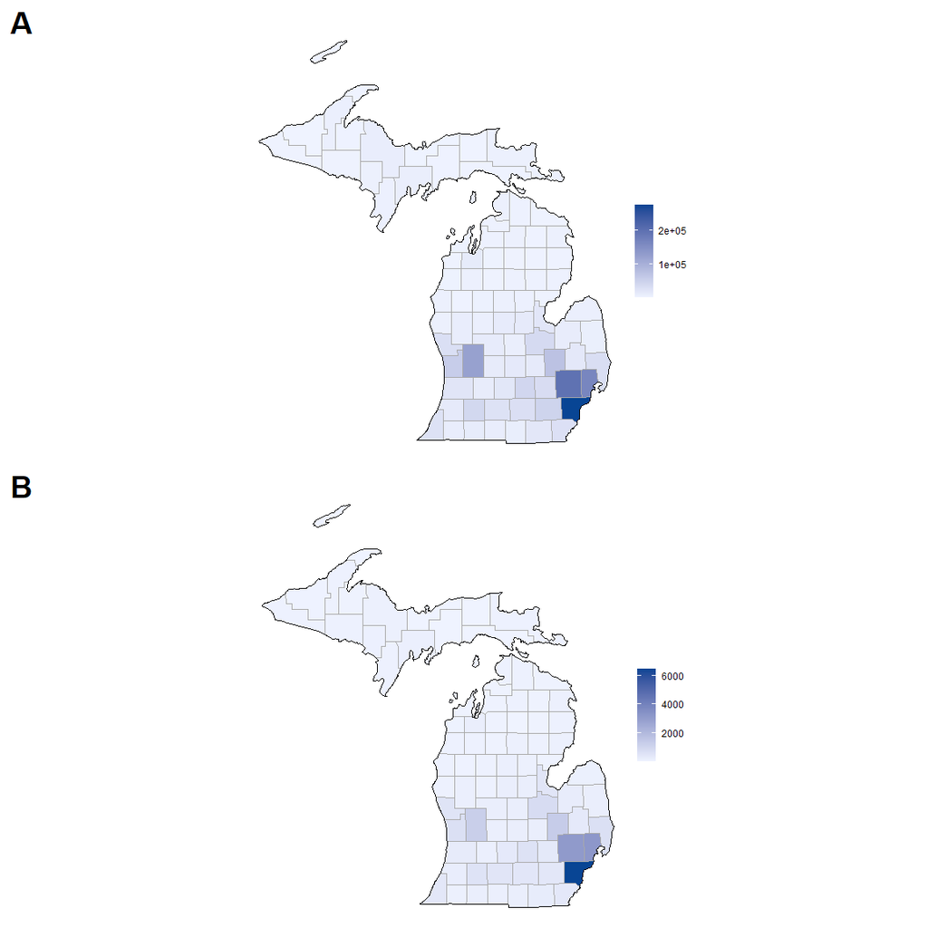

**Figure 1:** Distribution of Covid cases and deaths across the state of Michigan

## State Overall Trends

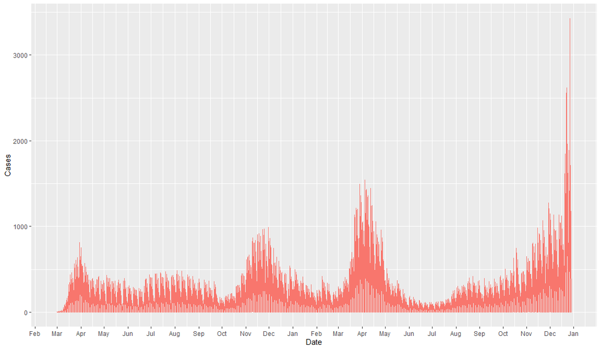

**Figure 2:** The monthly amount of cases throughout the entire state of Michigan

## Comparing Counties

The three counties that are included in this report are Oakland, Presque Isle, and Kalamazoo. There are significantly less cases in Presque Isle County than there are in the other two counties.

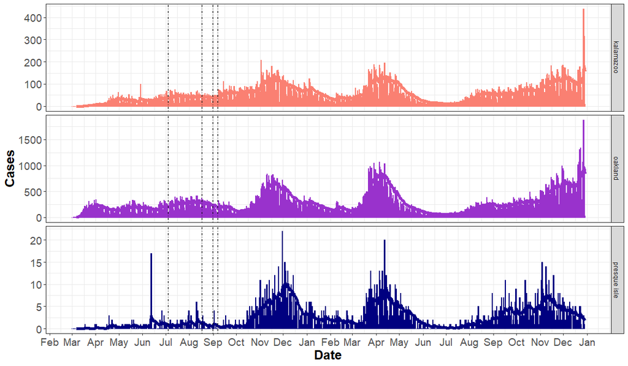

**Figure 3:** The monthly amount of Covid cases in Oakland County, Presque Isle County, and Kalamazoo County

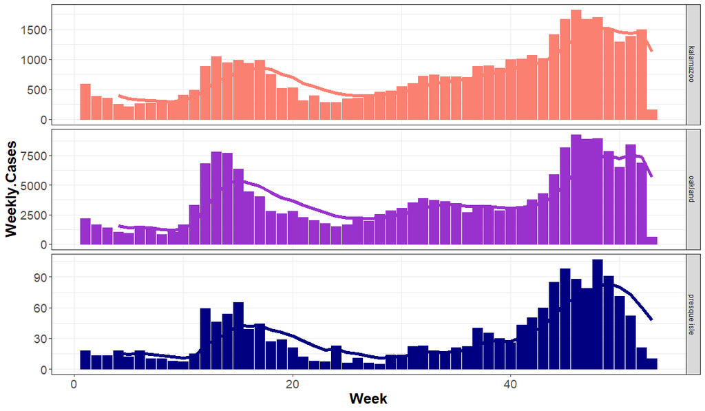

## References

No extra references were used.